# Fine root production

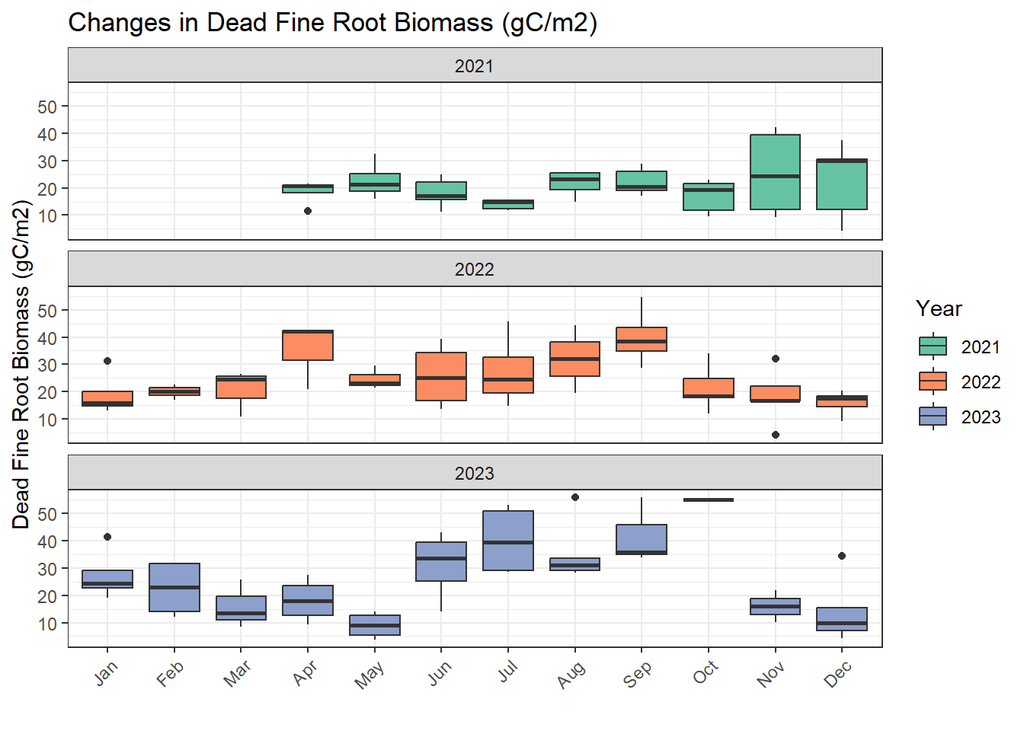

```r
# temporal changes in DF
# Now create your plot
p_df <- ggplot(root_plmean) +
  geom_boxplot(aes(x = month_name, y = DF_gC_mean, fill = factor(year))) +
  theme_bw() +
  xlab("") +
  ylab("Dead Fine Root Biomass (gC/m2)") +
  ggtitle("Changes in Dead Fine Root Biomass (gC/m2)") +
  scale_fill_brewer(palette = "Set2", name = "Year") +
  facet_wrap(~ year, ncol = 1) +
  theme(axis.text.x = element_text(angle = 45, hjust = 1))

print(p_df)
```

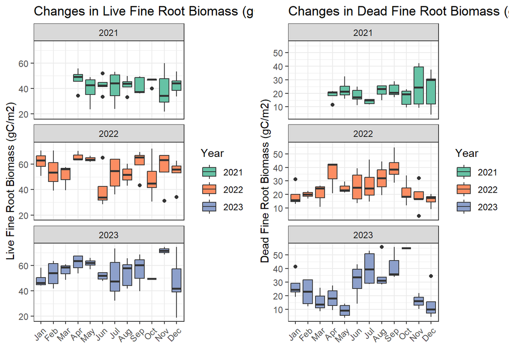

```r
grid.arrange(p_lf,p_df, ncol= 2)
```

```r
################################################################################
# PREPARE PLOT-LEVEL DATA FOR PRODUCTION ESTIMATION
################################################################################

# Sort by plot and date
root_plmean  <- root_plmean %>%
  arrange(Plot, year, month_num, month_name) %>%
  ungroup() %>%
  mutate(MY = paste(year, month_num, sep = "-")) # Add month-year identifier

# Build a proper month index using numeric year/month
unique_MY <- root_plmean%>%
  distinct(year, month_num) %>%
  arrange(year, month_num) %>%
  mutate(M = row_number())

root_plmean<- root_plmean%>%
  left_join(unique_MY, by = c("year","month_num"))

#root_plmean<- root_plmean%>% drop_na()
################################################################################
# REMOVE OCTOBER 2023 DATA (only 1 data point)
################################################################################

# Remove October 2023 from the dataset
root_plmean<- root_plmean%>%
  filter(!(year == 2023 & month_num == 10))

# Now when you calculate differences, it will automatically skip October
# and calculate Nov-Sept difference instead

# Calculate differences between consecutive months AT PLOT LEVEL
root_diff_plot <- root_plmean%>%
  group_by(Plot) %>%  # KEY: Group by plot to track each plot's time series
  arrange(Plot, year, month_num) %>%
  mutate(
    LF_diff = LF_gC_mean - lag(LF_gC_mean),
    DF_diff = DF_gC_mean - lag(DF_gC_mean),
    MY_diff = M - lag(M)
  ) %>%
  ungroup()
```

### Method 1 (P: Harris 1977,; M: Joslin 1987 ??).

P = the sum of the LF increments

### Method 2: Decision matrix (Gower 1992). (dcs_)

## 3-month sample interval

## modified from MacClaugherty et al 1982 & Fairley and Alexander 1985

Production can be negatvie Four cases present: 1: LF increase, DF increase / P= L+D, M = D 2: LF increase, DF decrease / P = L, M = L 3: LF decrease, DF increase / P = L+D, M = D 4: LF decrease, DF decrease / P = 0, M = L

### Method 4: Decision matrix by Assefa 2017 & Brunner 2011. (dcs2_)

This method doesnt give neg production ## Modified from Method 1 to prevent negative production ## Four cases present: ## 1: LF increase, DF increase / P = L+D (if L+D > 0, else 0), M = D ## 2: LF increase, DF decrease / P = L, M = 0 or abs(L) ## 3: LF decrease, DF increase / P = L+D (if L+D > 0, else 0), M = abs(L) or D ## 4: LF decrease, DF decrease / P = 0, M = abs(L)

### Method 5: Decision matrix by Yuan 2013. (dcs3_)

Similar to method 2 for production, mortality estimates differ

## 3: LF increase, DF decrease / P = L, M = 0

## 4: LF decrease, DF decrease / P = 0, M = |L|

```r
################################################################################
#DEFINE PRODUCTION ESTIMATION FUNCTION
################################################################################

root_estimation <- function(df){
  df <- df %>%
    mutate(m1_p = ifelse(LF_diff > 0, LF_diff, 0),
           ############################################
           dcs_p = case_when(DF_diff > 0 ~ LF_diff + DF_diff,
                             DF_diff < 0 ~
                               ifelse(LF_diff > 0, LF_diff, 0)),
           dcs_m = case_when(DF_diff > 0 ~ DF_diff,
                             DF_diff < 0 ~ LF_diff),
           #############################################
           dcs2_p = case_when(DF_diff > 0 ~
                                ifelse(LF_diff + DF_diff > 0,
                                       LF_diff + DF_diff, 0),
                              DF_diff < 0 ~
                                ifelse(LF_diff > 0, LF_diff, 0)),
           dcs2_m = case_when(DF_diff > 0 ~
                                ifelse(LF_diff + DF_diff > 0,
                                       DF_diff, abs(LF_diff)),
                              DF_diff < 0 ~ abs(LF_diff)),
           dcs2_d = case_when(DF_diff > 0 & LF_diff > 0 ~ 0,
                              DF_diff > 0 & LF_diff < 0 ~
                                ifelse(abs(LF_diff) > DF_diff,
                                       abs(LF_diff) - DF_diff, 0),
                              DF_diff < 0 & LF_diff > 0 ~ abs(DF_diff),
                              DF_diff < 0 & LF_diff < 0 ~ abs(DF_diff) + abs(LF_diff)),
           #####################################################
           dcs3_p = case_when(DF_diff > 0 ~
                                ifelse(LF_diff + DF_diff > 0,
                                       LF_diff + DF_diff, 0),
                              DF_diff < 0 ~
                                ifelse(LF_diff > 0, LF_diff, 0)),
           dcs3_m = case_when(DF_diff > 0 ~
                                ifelse(LF_diff + DF_diff > 0,
                                       DF_diff, abs(LF_diff)),
                              DF_diff < 0 ~
                                ifelse(LF_diff > 0,
                                       0, abs(LF_diff))),
           dcs3_d = case_when(DF_diff > 0 ~
                                ifelse(LF_diff + DF_diff > 0,
                                       0, abs(LF_diff + DF_diff)),
                              DF_diff < 0 & LF_diff > 0 ~ abs(DF_diff),
                              DF_diff < 0 & LF_diff < 0 ~ abs(DF_diff + LF_diff)),
           #######################################################################
           dcs4_p = case_when(DF_diff > 0 & LF_diff > 0 ~ LF_diff + DF_diff,
                              DF_diff > 0 & LF_diff < 0 ~ pmin(LF_diff + DF_diff, 0), # pmin is for multiple vectors
                              DF_diff < 0 ~
                                ifelse(LF_diff > 0, LF_diff, 0)),
           dcs4_m = case_when(DF_diff > 0 & LF_diff > 0 ~ DF_diff,
                              DF_diff > 0 & LF_diff < 0 ~ pmin(DF_diff, abs(LF_diff)),
                              DF_diff < 0 ~ abs(LF_diff)),
           dcs4_d = case_when(DF_diff > 0 & LF_diff > 0 ~ 0,
                              DF_diff > 0 & LF_diff < 0 ~ pmin(abs(LF_diff-DF_diff), 0),
                              DF_diff < 0 & LF_diff > 0 ~ abs(DF_diff),
                              DF_diff < 0 & LF_diff < 0 ~ abs(DF_diff) + abs(LF_diff)),
           #####################################################
           cmp_m_temp = DF_diff + 0.06*MY_diff*lag(DF_gC_mean)) %>%
    mutate(cmp_m = ifelse(cmp_m_temp < 0, 0, cmp_m_temp)) %>%
    mutate(cmp_p = LF_diff + cmp_m)

  return(df)
}

# Apply estimation function
root_est_plot <-
  root_estimation(root_diff_plot)
```

ROot estimation plot means

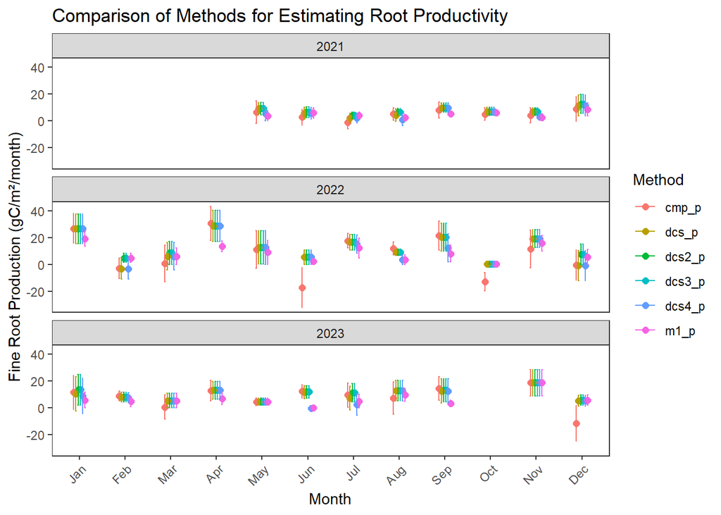

```r
# First, pivot longer to get each method in its own row
root_est_plot_monthly <- root_est_plot %>%
  pivot_longer(
    cols = c(m1_p, dcs_p, dcs2_p, dcs3_p, dcs4_p, cmp_p),
    names_to = "Method",
    values_to = "Production"
  ) %>%
  group_by(Method, year, month_num, month_name) %>%
  summarise(
    n_plots = sum(!is.na(Production)),
    prod_mean = mean(Production, na.rm = TRUE),
    prod_sd = sd(Production, na.rm = TRUE),
    prod_se = prod_sd / sqrt(n_plots),
    .groups = "drop"
  ) %>%
  mutate(month_name = factor(month_name, levels = month_order, ordered = TRUE)) %>%
  arrange(year, month_num, Method)


ggplot(root_est_plot_monthly, aes(x = month_name, y = prod_mean, color = Method)) +
  geom_point(position = position_dodge(width = 0.3), size = 2) +
  geom_errorbar(aes(ymin = prod_mean - prod_se, ymax = prod_mean + prod_se),
                width = 0.2, position = position_dodge(width = 0.3)) +
  facet_wrap(~ year, ncol = 1) +
  theme_bw() +
  xlab("Month") +
  ylab("Fine Root Production (gC/m²/month)") +
  ggtitle("Comparison of Methods for Estimating Root Productivity") +
  theme(axis.text.x = element_text(angle = 45, hjust = 1),
        legend.position = "right",
        panel.grid.major = element_blank(),
        panel.grid.minor = element_blank())
```

Plot

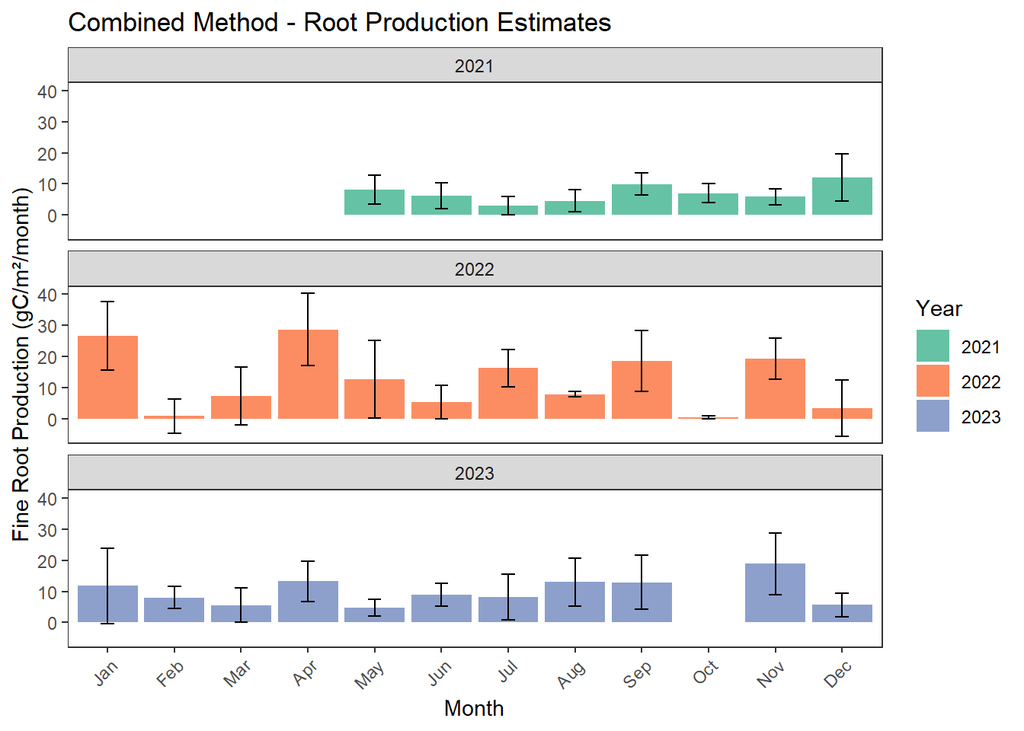

```r
root_est_monthly <- root_est_plot %>%
  mutate(
    prod_mean = rowMeans(
      select(., c(dcs_p, dcs2_p, dcs3_p, dcs4_p)),
      na.rm = TRUE
    )
  ) %>%
  group_by(year, month_num, month_name, Plot) %>%
  summarise(
    prod_plot_mean = mean(prod_mean, na.rm = TRUE),
    .groups = "drop"
  ) %>%
  group_by(year, month_num, month_name) %>%
  summarise(
    n_plots = sum(!is.na(prod_plot_mean)),
    prod_mean = mean(prod_plot_mean, na.rm = TRUE),
    prod_sd = sd(prod_plot_mean, na.rm = TRUE),
    prod_se = prod_sd / sqrt(n_plots),
    .groups = "drop"
  ) %>%
  mutate(month_name = factor(month_name, levels = month_order, ordered = TRUE)) %>%
  arrange(year, month_num)


ggplot(root_est_monthly, aes(x = month_name, y = prod_mean, fill = factor(year))) +
  geom_bar(stat = "identity", position = "dodge") +
  geom_errorbar(aes(ymin = prod_mean - prod_se, ymax = prod_mean + prod_se),
                width = 0.2, position = position_dodge(width = 0.9)) +
  facet_wrap(~ year, ncol = 1) +
  theme_bw() +
  xlab("Month") +
  ylab("Fine Root Production (gC/m²/month)") +
  ggtitle("Combined Method - Root Production Estimates") +
  scale_fill_brewer(palette = "Set2", name = "Year") +
  theme(axis.text.x = element_text(angle = 45, hjust = 1),
        legend.position = "right",
        panel.grid.major = element_blank(),
        panel.grid.minor = element_blank())
```

Save data

```r
# Save the monthly production by method (for comparison figure)
write_csv(root_est_plot_monthly,
          "C:/Benju/R_data_play/Southern Pine Data Analysis/Output/root_production_by_method_monthly.csv")

# Save the combined method monthly production (for bar plot)
write_csv(root_est_monthly,
          "C:/Benju/R_data_play/Southern Pine Data Analysis/Output/root_production_combined_monthly.csv")
```